# Análisis del rendimiento del el test minimental después de tres intervenciones no farmacológicos

Cuaderno de análisis de datos

Author

Affiliation

John Felipe Arias, MsC

Universidad San Buenaventura

Published

Monday, November 25, 2024

Keywords

Test Minimental, Rendimiento psicológico, Intervenciones no famacológicas

# 1 Introduccion

# 2 Instalación de paquetes

A continuación se instalan los paquetes necesarios para desarrollar el modelo estadístico.

```r
if (!require("brms")) install.packages("brms")
if (!require("dplyr")) install.packages("dplyr")
if (!require("ggalluvial")) install.packages("ggalluvial")
if (!require("ggplot2")) install.packages("ggplot2")
if (!require("glmmTMB")) install.packages("glmmTMB")
if (!require("here")) install.packages("here")
if (!require("performance")) install.packages("performance")
if (!require("readxl")) install.packages("readxl")
```

# 3 Cargar los datos

En primer lugar, cargamos la tabla “Data/INT_Anxiety_minimental.xlsx” que contiene los resultados del test minimental y otras variables de identificacióin.

```r
tdcs_mmse_anxiety <- read_xlsx (here("Data/INT_Anxiety_minimental.xlsx"))
head(tdcs_mmse_anxiety)
```

```
# A tibble: 6 × 14
  Medicion  Tdcs Mindfulness Intervencion DS_email DS_Tel DS_Edad DS_Estrato
     <dbl> <dbl>       <dbl> <chr>        <chr>     <dbl>   <dbl> <chr>
1        1     0           1 Mindfulness  fdsd        545      12 E1
2        1     0           1 Mindfulness  sdsad      4545      58 E1
3        1     0           1 Mindfulness  sdsad      8545      26 E1
4        1     0           1 Mindfulness  sdsad     12545      21 E3
5        1     0           1 Mindfulness  fdsd      16545      52 E3
6        1     0           1 Mindfulness  sdsad     20545      35 E5
# ℹ 6 more variables: DS_Medicamento <chr>, DS_Sexo <chr>,
#   MMSE_Orientación <dbl>, MMSE_FyRinmediato <dbl>,
#   MMSE_Atencion_Calculo <dbl>, MMSE_total <dbl>
```

A continuación exploramos la estructura de los datos

```r
str(tdcs_mmse_anxiety)
```

```
tibble [80 × 14] (S3: tbl_df/tbl/data.frame)
 $ Medicion             : num [1:80] 1 1 1 1 1 1 1 1 1 1 ...
 $ Tdcs                 : num [1:80] 0 0 0 0 0 0 0 1 1 1 ...
 $ Mindfulness          : num [1:80] 1 1 1 1 1 1 1 0 0 0 ...
 $ Intervencion         : chr [1:80] "Mindfulness" "Mindfulness" "Mindfulness" "Mindfulness" ...
 $ DS_email             : chr [1:80] "fdsd" "sdsad" "sdsad" "sdsad" ...
 $ DS_Tel               : num [1:80] 545 4545 8545 12545 16545 ...
 $ DS_Edad              : num [1:80] 12 58 26 21 52 35 12 58 26 21 ...
 $ DS_Estrato           : chr [1:80] "E1" "E1" "E1" "E3" ...
 $ DS_Medicamento       : chr [1:80] "Si" "Si" "Si" "Si" ...
 $ DS_Sexo              : chr [1:80] "M" "H" "M" "H" ...
 $ MMSE_Orientación     : num [1:80] 5 5 9 6 7 5 2 9 4 7 ...
 $ MMSE_FyRinmediato    : num [1:80] 2 2 1 2 1 2 1 2 3 2 ...
 $ MMSE_Atencion_Calculo: num [1:80] 4 5 4 4 4 4 4 4 6 4 ...
 $ MMSE_total           : num [1:80] 11 12 14 12 12 11 7 15 13 13 ...
```

De esta tabla estamos interesados en las variables “Medicion”, que indica la semanas en las que se llevó a cabo la reccolleción de datos de la prueba. “Intervencion”, una variable de agrupación que indica el grupo o tratamiento que recibió cada perticipante. “DS_Edad” nos indica la edad en años del participante y “DS_Sexo” nos indica el sexo biológico del pparticipante. Finalnmente, tomamos “MMSE_Total” como la variable que nos indica el resultado final del test.

En primer lugar, debemos transformar las variables “Intervención” y “Sexo” en categorías. El resto de variables las consideraremos como numéricas.

```r
tdcs_mmse_anxiety <- tdcs_mmse_anxiety %>%
  mutate(
    Intervencion = factor(Intervencion, levels = c("Mindfulness", "Tdcs","combinado")),
    DS_Sexo = factor(DS_Sexo, levels = c("H", "M"))
  )

str(tdcs_mmse_anxiety)
```

```
tibble [80 × 14] (S3: tbl_df/tbl/data.frame)
 $ Medicion             : num [1:80] 1 1 1 1 1 1 1 1 1 1 ...
 $ Tdcs                 : num [1:80] 0 0 0 0 0 0 0 1 1 1 ...
 $ Mindfulness          : num [1:80] 1 1 1 1 1 1 1 0 0 0 ...
 $ Intervencion         : Factor w/ 3 levels "Mindfulness",..: 1 1 1 1 1 1 1 2 2 2 ...
 $ DS_email             : chr [1:80] "fdsd" "sdsad" "sdsad" "sdsad" ...
 $ DS_Tel               : num [1:80] 545 4545 8545 12545 16545 ...
 $ DS_Edad              : num [1:80] 12 58 26 21 52 35 12 58 26 21 ...
 $ DS_Estrato           : chr [1:80] "E1" "E1" "E1" "E3" ...
 $ DS_Medicamento       : chr [1:80] "Si" "Si" "Si" "Si" ...
 $ DS_Sexo              : Factor w/ 2 levels "H","M": 2 1 2 1 2 2 2 2 2 1 ...
 $ MMSE_Orientación     : num [1:80] 5 5 9 6 7 5 2 9 4 7 ...
 $ MMSE_FyRinmediato    : num [1:80] 2 2 1 2 1 2 1 2 3 2 ...
 $ MMSE_Atencion_Calculo: num [1:80] 4 5 4 4 4 4 4 4 6 4 ...
 $ MMSE_total           : num [1:80] 11 12 14 12 12 11 7 15 13 13 ...
```

Confirmamos que los factores han sido ajustados correctamente.

# 4 Visualización exploratoria de los datos

En primer lugar, implementamos un grupo de funciones estéticas para mejorar la apariencia de nuestros plots.

```r
Plot_theme <- theme_classic() +
  theme(
      plot.title = element_text(size=18, hjust = 0.5, face="bold"),
      plot.subtitle = element_text(size = 10, color = "black"),
      plot.caption = element_text(size = 12, color = "black"),
      axis.line = element_line(colour = "black", linewidth = 1.5, linetype = "solid"),
      axis.ticks.length=unit(7,"pt"),

      axis.title.x = element_text(colour = "black", size = 16),
      axis.text.x = element_text(colour = "black", size = 16, angle = 0, hjust = 0.5),
      axis.ticks.x = element_line(colour = "black", linewidth = 1),

      axis.title.y = element_text(colour = "black", size = 16),
      axis.text.y = element_text(colour = "black", size = 16),
      axis.ticks.y = element_line(colour = "black", linewidth = 1),

      legend.position="right",
      legend.direction="vertical",
      legend.title = element_text(colour="black", face="bold", size=12),
      legend.text = element_text(colour="black", size=10),

      plot.margin = margin(t = 10,  # Top margin
                             r = 2,  # Right margin
                             b = 10,  # Bottom margin
                             l = 10) # Left margin
      )
```

Ahora, visualizamos la distribución de los datos por medición, intervención y sexo.

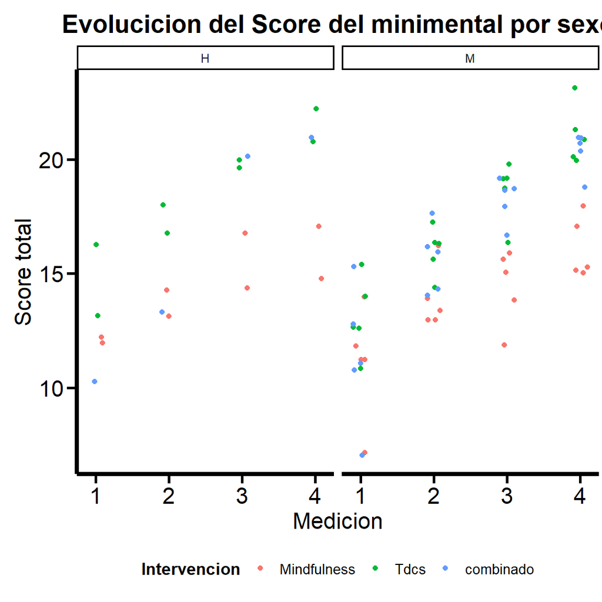

Figure 1: Evolucicion del Score del minimental por sexo

```r
MMSE_Total_Expl <- ggplot(
tdcs_mmse_anxiety,
  aes(
    x = Medicion,
    y = `MMSE_total`,
    color = Intervencion
  )
) +
  geom_point(position = position_jitter(width = 0.1)) +
  labs(y = "Score total")+
  ggtitle("Evolucicion del Score del minimental por sexo")+
  Plot_theme +
  theme(legend.position = "bottom",
        legend.direction = "horizontal") +
  facet_wrap(~ DS_Sexo)


ggsave(MMSE_Total_Expl,
       filename = here("Plots/MMSE_ScoreTotal.png"),
       width    = 12,
       height   = 12,
       units    = "cm")

MMSE_Total_Expl
```

Figure 1 nos muestra que el escore parece aumentar con el transcurso del tiempo para todas las intervenciones. No se aprecia una sustancial entre hombres y muejres. Consideraremos el tiempo, la intervención, y el sexo en nuestra regresión, y veremos además si la edad tiene un efecto relevante.

# 5 Modelamiento estadístico - Efecto de la intervención y la medición (Modelo 1).

En pimer lugar, utilizamos una distribución de student para ajustar el siguiente modelo

$$MMSE\_total_i = \beta_0 + \beta_1 \times Medicion_i + \beta_2 \times Intervencion_i + \beta_3 \times (Medicion_i \times Intervencion_i) + \epsilon_i$$
donde $\beta_0$ es el intercepto, que representa el puntaje base de la medicion (0) y la intervención (mindfullness).$\beta_1$ es el efecto de la medición (tiempo). $\beta_2$ son los coefficientes que representan el efecto de cada intervención y $\beta_3$ es la interacción entre la medición y la intervención. Finalmente, $\epsilon_i$ representa el error que sigue una distribución student-t

## 5.1 Ajuste del modelo

```r
MMSE_Mdl1 <- bf(MMSE_total ~ Medicion * Intervencion)

get_prior(MMSE_Mdl1, tdcs_mmse_anxiety)
```

```
                 prior     class                           coef group resp dpar
                (flat)         b
                (flat)         b          Intervencioncombinado
                (flat)         b               IntervencionTdcs
                (flat)         b                       Medicion
                (flat)         b Medicion:Intervencioncombinado
                (flat)         b      Medicion:IntervencionTdcs
 student_t(3, 16, 4.4) Intercept
  student_t(3, 0, 4.4)     sigma
 nlpar lb ub       source
                  default
             (vectorized)
             (vectorized)
             (vectorized)
             (vectorized)
             (vectorized)
                  default
        0         default
```

```r
MMSE_Fit1 <-
  brm(
    data = tdcs_mmse_anxiety,
    family = student,
    formula = MMSE_Mdl1,
    chains = 4,
    cores = 4,
    warmup = 2500,
    iter = 5000,
    seed = 8807,
    control = list(adapt_delta = 0.99, max_treedepth = 15),
    file = here("Models/MMSE_Fit1.rds"),
    file_refit = "never"
  )
```

A continuación vemos la tabla de resultados:

## 5.2 Tabla de resultados

```r
summary(MMSE_Fit1)
```

```
 Family: student
  Links: mu = identity; sigma = identity; nu = identity
Formula: MMSE_total ~ Medicion * Intervencion
   Data: tdcs_mmse_anxiety (Number of observations: 80)
  Draws: 4 chains, each with iter = 5000; warmup = 2500; thin = 1;
         total post-warmup draws = 10000

Regression Coefficients:
                               Estimate Est.Error l-95% CI u-95% CI Rhat
Intercept                         10.38      0.72     8.96    11.79 1.00
Medicion                           1.45      0.26     0.94     1.98 1.00
IntervencionTdcs                   0.81      1.02    -1.16     2.84 1.00
Intervencioncombinado             -1.75      1.10    -3.88     0.42 1.00
Medicion:IntervencionTdcs          1.08      0.37     0.35     1.81 1.00
Medicion:Intervencioncombinado     1.65      0.39     0.89     2.44 1.00
                               Bulk_ESS Tail_ESS
Intercept                          3670     4662
Medicion                           3613     4732
IntervencionTdcs                   3523     4319
Intervencioncombinado              3702     5166
Medicion:IntervencionTdcs          3387     4494
Medicion:Intervencioncombinado     3532     4683

Further Distributional Parameters:
      Estimate Est.Error l-95% CI u-95% CI Rhat Bulk_ESS Tail_ESS
sigma     1.42      0.16     1.12     1.75 1.00     5474     4776
nu       17.10     12.21     3.91    49.47 1.00     5680     5648

Draws were sampled using sampling(NUTS). For each parameter, Bulk_ESS
and Tail_ESS are effective sample size measures, and Rhat is the potential
scale reduction factor on split chains (at convergence, Rhat = 1).
```

Los resultados indican que la medición base para mindfullnes es 10.38 (95% CI = 8.96 to 11.79). El tiempo (medición) indica que el score mejora en 1.45 (95% CI 0.94 - 1.98) para el grupo mindfullnes por cada semana que pasa. Por otra parte, el coeffiente para “IntervencionTdcs” nos dice que el score base para el grupo tDCS es en promedio un poco más alto que para mindfullness (0.81), aunque posee una considerable incertidumbre (95% cI = -1.16 - 2.84). Esto nos indca que el puntaje base para este grupo puede ser menor, igual o superior que el del grupo mindfullness. El grupo combinado, por su parte, tiene una medición base menor que el grupo mindfulness (−1.75, 95% cI = -3.88 - 0.42), nuevamente con una considerable incertidumbre.

Por otra parte, los coeficientes de interacción nos indican que, en primer lugar (Medicion:IntervencionTdcs), el grupo tDCS muestra un incremento adicional de 1.08 en los scores del MMSE con el tiempo comparado con el grupo mindfullness. el intervalo de credibilidad permite concluir que el efecto es probablemente positivo (95 CI = 0.35 - 1.81). Para el grupo combinado (Medicion:Intervencioncombinado), podemos apreciar un incremento adicional de 1.65 points en los scores del MMSE con el tiempo relativo al grupo mindfulness. Del mismo modo, el intervalo de credibilidad sugiere que el efecto es positivo (0.89 - 2.44).

## 5.3 Visualización de resultados

A continuación visualizamos los resultados:

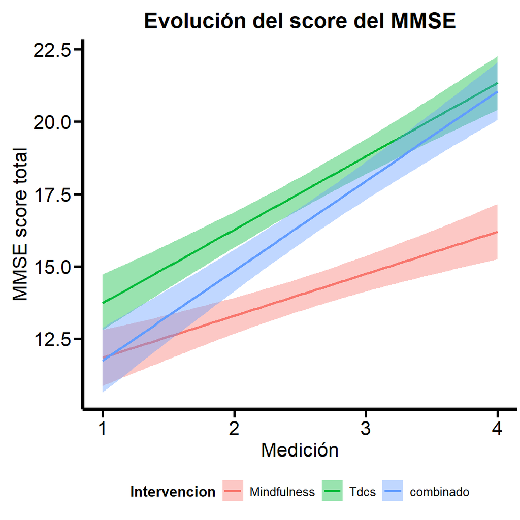

```r
MMSE_CE <- conditional_effects(MMSE_Fit1)

MMSE_CE_Fig <- plot(MMSE_CE , plot = FALSE)[[3]]

MMSE_CE_Fig <- MMSE_CE_Fig +
  labs(title = "Evolución del score del MMSE",
       y = "MMSE score total",
       x = "Medición") +
  Plot_theme +
  theme(legend.position = "bottom",
        legend.direction = "horizontal")

ggsave (MMSE_CE_Fig,
        file = here("Plots/MMSE_Fit1.jpg"),
        width = 12,
        height = 12,
        units = "cm")

MMSE_CE_Fig
```

A pesar de que la exploración inicial de los datos sugiere que no existe una diferencia por sexo, incluiremos esta variable dentro de la regresión para propósitos educativos.

# 6 Modelamiento estadístico - Efecto del sexo (Modelo 2).

Ahora ajustamos un modelo con la siguiente formulacion:

```r
MMSE_Mdl2 <- bf(MMSE_total ~ Medicion * Intervencion + DS_Sexo)

get_prior(MMSE_Mdl2, tdcs_mmse_anxiety)
```

```
                 prior     class                           coef group resp dpar
                (flat)         b
                (flat)         b                       DS_SexoM
                (flat)         b          Intervencioncombinado
                (flat)         b               IntervencionTdcs
                (flat)         b                       Medicion
                (flat)         b Medicion:Intervencioncombinado
                (flat)         b      Medicion:IntervencionTdcs
 student_t(3, 16, 4.4) Intercept
  student_t(3, 0, 4.4)     sigma
 nlpar lb ub       source
                  default
             (vectorized)
             (vectorized)
             (vectorized)
             (vectorized)
             (vectorized)
             (vectorized)
                  default
        0         default
```

```r
MMSE_Fit2 <-
  brm(
    data = tdcs_mmse_anxiety,
    family = student,
    formula = MMSE_Mdl2,
    chains = 4,
    cores = 4,
    warmup = 2500,
    iter = 5000,
    seed = 8807,
    control = list(adapt_delta = 0.99, max_treedepth = 15),
    file = here("Models/MMSE_Fit2.rds"),
    file_refit = "never"
  )
```

A continuación vemos la tabla de resultados:

## 6.1 Tabla de resultados

```r
summary(MMSE_Fit2)
```

```
 Family: student
  Links: mu = identity; sigma = identity; nu = identity
Formula: MMSE_total ~ Medicion * Intervencion + DS_Sexo
   Data: tdcs_mmse_anxiety (Number of observations: 80)
  Draws: 4 chains, each with iter = 5000; warmup = 2500; thin = 1;
         total post-warmup draws = 10000

Regression Coefficients:
                               Estimate Est.Error l-95% CI u-95% CI Rhat
Intercept                         10.68      0.76     9.17    12.18 1.00
Medicion                           1.47      0.26     0.97     1.98 1.00
IntervencionTdcs                   0.89      1.00    -1.11     2.82 1.00
Intervencioncombinado             -1.61      1.13    -3.81     0.61 1.00
DS_SexoM                          -0.50      0.39    -1.26     0.28 1.00
Medicion:IntervencionTdcs          1.06      0.36     0.35     1.78 1.00
Medicion:Intervencioncombinado     1.63      0.40     0.84     2.40 1.00
                               Bulk_ESS Tail_ESS
Intercept                          4535     5361
Medicion                           3981     4829
IntervencionTdcs                   4394     5415
Intervencioncombinado              4017     5701
DS_SexoM                           9867     6798
Medicion:IntervencionTdcs          4189     5318
Medicion:Intervencioncombinado     3851     5126

Further Distributional Parameters:
      Estimate Est.Error l-95% CI u-95% CI Rhat Bulk_ESS Tail_ESS
sigma     1.42      0.16     1.11     1.75 1.00     6251     5945
nu       17.15     11.94     3.84    48.20 1.00     6409     6043

Draws were sampled using sampling(NUTS). For each parameter, Bulk_ESS
and Tail_ESS are effective sample size measures, and Rhat is the potential
scale reduction factor on split chains (at convergence, Rhat = 1).
```

Los resultados sugieren que el sexo no tiene un efecto sustancial el el puntaje del MMSE con el tiempo y la intervención (-0.50, 95% cI = -1.26 - 0.28).

## 6.2 Visualizacion

Podemos apreciar el resultado de manrea visual:

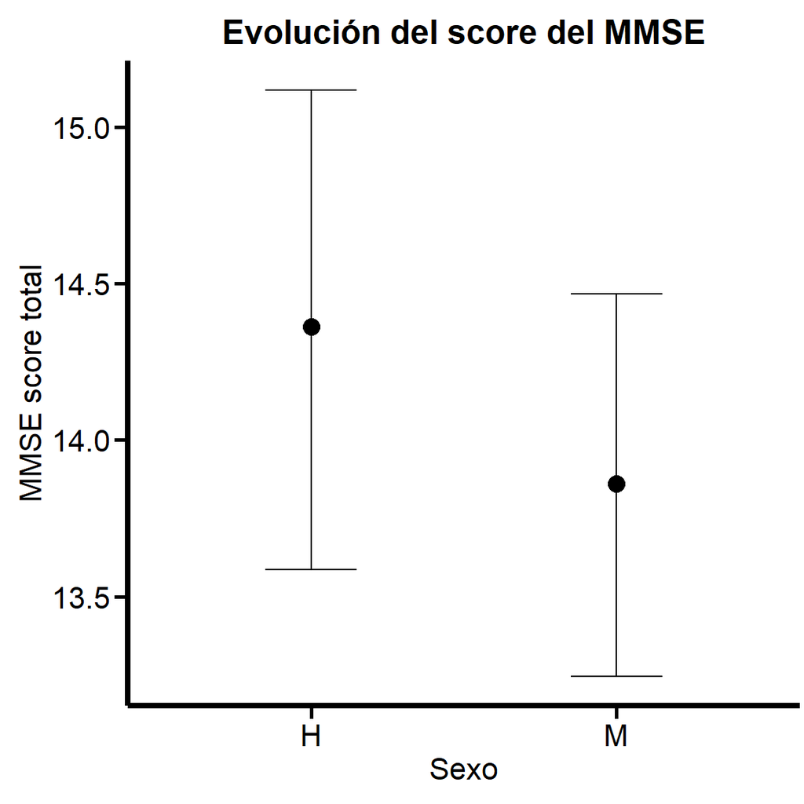

Figure 3: Evolucicion del Score del minimental por sexo

```r
MMSE_Fit2_CE <- conditional_effects(MMSE_Fit2)

MMSE_Fit2_CE_Fig <- plot(MMSE_Fit2_CE , plot = FALSE)[[3]]

MMSE_Fit2_CE_Fig <- MMSE_Fit2_CE_Fig +
  labs(title = "Evolución del score del MMSE",
       y = "MMSE score total",
       x = "Sexo") +
  Plot_theme


ggsave (MMSE_Fit2_CE_Fig,
        file = here("Plots/MMSE_Fit2.jpg"),
        width = 12,
        height = 12,
        units = "cm")

MMSE_Fit2_CE_Fig
```

# 7 Modelamiento estadístico - Efecto de la edad (Modelo 3).

Finalmente, investigamos el efecto de la edad el la evolución del puntaje del test.

```r
MMSE_Mdl3 <- bf(MMSE_total ~ Medicion * Intervencion + DS_Edad)

get_prior(MMSE_Mdl3, tdcs_mmse_anxiety)
```

```
                 prior     class                           coef group resp dpar
                (flat)         b
                (flat)         b                        DS_Edad
                (flat)         b          Intervencioncombinado
                (flat)         b               IntervencionTdcs
                (flat)         b                       Medicion
                (flat)         b Medicion:Intervencioncombinado
                (flat)         b      Medicion:IntervencionTdcs
 student_t(3, 16, 4.4) Intercept
  student_t(3, 0, 4.4)     sigma
 nlpar lb ub       source
                  default
             (vectorized)
             (vectorized)
             (vectorized)
             (vectorized)
             (vectorized)
             (vectorized)
                  default
        0         default
```

```r
MMSE_Fit3 <-
  brm(
    data = tdcs_mmse_anxiety,
    family = student,
    formula = MMSE_Mdl3,
    chains = 4,
    cores = 4,
    warmup = 2500,
    iter = 5000,
    seed = 8807,
    control = list(adapt_delta = 0.99, max_treedepth = 15),
    file = here("Models/MMSE_Fit3.rds"),
    file_refit = "never"
  )
```

A continuación vemos la tabla de resultados:

## 7.1 Tabla de resultados

```r
summary(MMSE_Fit3)
```

```
 Family: student
  Links: mu = identity; sigma = identity; nu = identity
Formula: MMSE_total ~ Medicion * Intervencion + DS_Edad
   Data: tdcs_mmse_anxiety (Number of observations: 80)
  Draws: 4 chains, each with iter = 5000; warmup = 2500; thin = 1;
         total post-warmup draws = 10000

Regression Coefficients:
                               Estimate Est.Error l-95% CI u-95% CI Rhat
Intercept                         10.71      0.81     9.06    12.28 1.00
Medicion                           1.44      0.26     0.94     1.98 1.00
IntervencionTdcs                   0.81      1.00    -1.15     2.76 1.00
Intervencioncombinado             -1.75      1.11    -3.91     0.45 1.00
DS_Edad                           -0.01      0.01    -0.03     0.01 1.00
Medicion:IntervencionTdcs          1.10      0.36     0.40     1.82 1.00
Medicion:Intervencioncombinado     1.66      0.39     0.87     2.43 1.00
                               Bulk_ESS Tail_ESS
Intercept                          3772     4949
Medicion                           3347     4875
IntervencionTdcs                   3545     5653
Intervencioncombinado              3488     5550
DS_Edad                            8670     6964
Medicion:IntervencionTdcs          3461     5095
Medicion:Intervencioncombinado     3262     4904

Further Distributional Parameters:
      Estimate Est.Error l-95% CI u-95% CI Rhat Bulk_ESS Tail_ESS
sigma     1.42      0.16     1.10     1.75 1.00     6042     6071
nu       16.45     12.01     3.65    48.70 1.00     5879     6362

Draws were sampled using sampling(NUTS). For each parameter, Bulk_ESS
and Tail_ESS are effective sample size measures, and Rhat is the potential
scale reduction factor on split chains (at convergence, Rhat = 1).
```

Al igual que la anterior variable, los resultados indican que la edad no tiene un efecto sustancial en el puntaje del MMSE.

## 7.2 Visualizacion

Podemos apreciar el resultado de manrea visual:

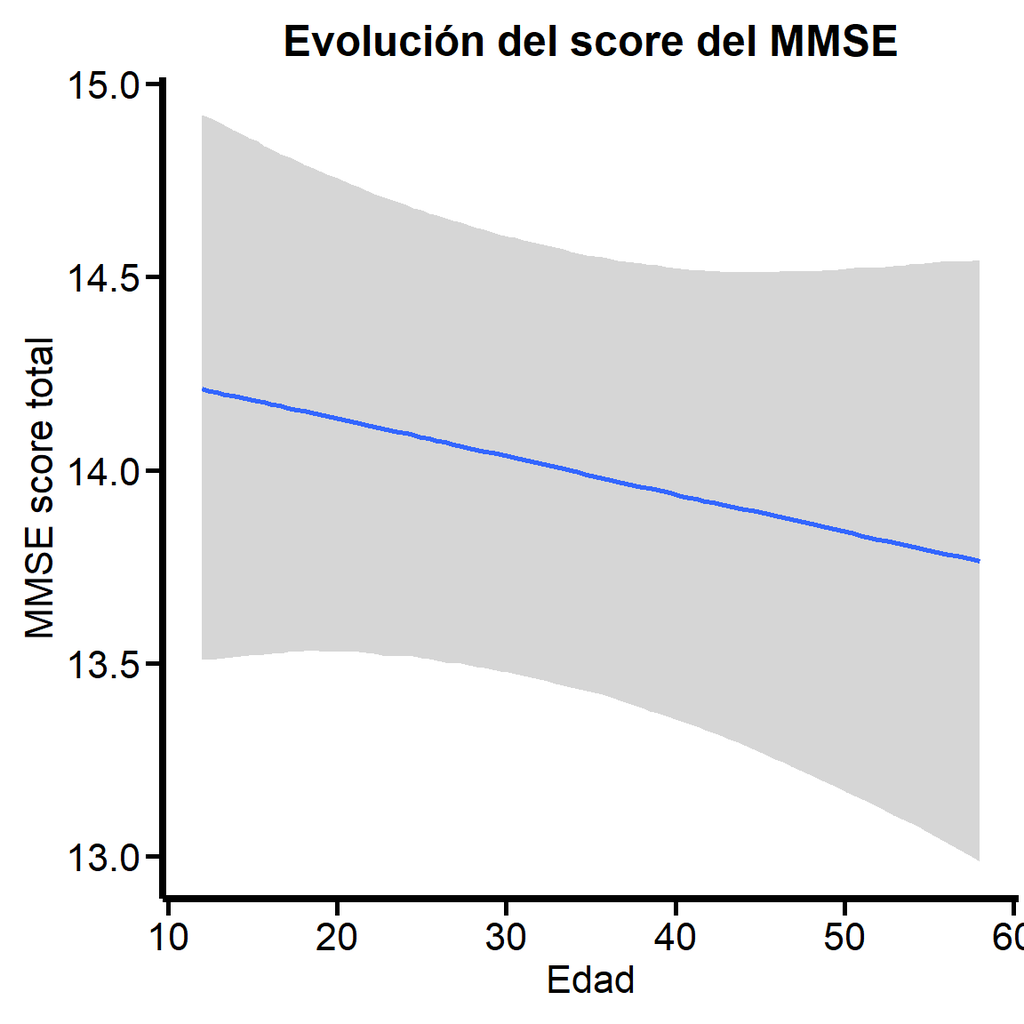

Figure 4: Evolucicion del Score del minimental por edad

```r
MMSE_Fit3_CE <- conditional_effects(MMSE_Fit3)

MMSE_Fit3_CE_Fig <- plot(MMSE_Fit3_CE , plot = FALSE)[[3]]

MMSE_Fit3_CE_Fig <- MMSE_Fit3_CE_Fig +
  labs(title = "Evolución del score del MMSE",
       y = "MMSE score total",
       x = "Edad") +
  Plot_theme


ggsave (MMSE_Fit3_CE_Fig,
        file = here("Plots/MMSE_Fit3.jpg"),
        width = 12,
        height = 12,
        units = "cm")

MMSE_Fit3_CE_Fig
```